# Project 1 - data exploration and visualization

**Source of data:**  
wget http://mlr.cs.umass.edu/ml/machine-learning-databases/census-income/census-income.data  
**Features:**  
age: continuous  
workclass: categorical  
fnlwgt: continuous  
education: categorical  
education-num: continuous  
marital-status: categorical  
occupation: categorical  
relationship: categorical  
race: categorical  
sex: binary  
capital-gain: continuous  
capital-loss: continuous  
hours-per-week: continuous  
native-country: categorical  
class: binary (>50K, <=50K)

### 1 Download and read data

```r
data <- read.table("./data/census-income.data", sep = ",", na.strings = "?", strip.white = TRUE)
```

```r
colnames(data) <- c("age", "workclass", "fnlwgt", "education", "education-num", "marital-status", "occupation", "relationship", "race", "sex", "capital-gain", "capital-loss", "hours-per-week", "native-country", "class")
```

### 2 Handle missing data

Level of all missing values.

```r
cat("Number of missings:",sum(is.na(data)))
```

```
## Number of missings: 4262
```

Number of rows with at least one missing value.

```r
cat("Number of missing rows:",sum(apply(is.na(data), 1, max)))
```

```
## Number of missing rows: 2399
```

Share of rows wiht at least one missing value.

```r
cat("Share of missing rows:", round(sum(apply(is.na(data), 1, max)) / (dim(data)[1]) * 100,2), "%")
```

```
## Share of missing rows: 7.37 %
```

Level of missing values by column. Print only these where number of missing values is greater then 0.

```r
na_col <- lapply(data, function(x) round(sum(is.na(x)) / dim(data)[1] * 100, 2))
na_col <- na_col[na_col > 0]
print(na_col)
```

```
## $workclass
## [1] 5.64
##
## $occupation
## [1] 5.66
##
## $`native-country`
## [1] 1.79
```

In this case there is ~7% rows with at least one missing value. For now missings won’t be ommited in explanatory data analysis.

```r
#data.pre <- data[complete.cases(data),]
data.pre <- data
```

### 3 Visualization ‘sex’

Load additional libraries to visualize data.

```r
library(lattice)
library(ggplot2)
library(dplyr)
```

Prepare data before plotting barplot. We need to compute shares of all categories.

```r
table <- as.data.frame(table(data.pre$sex))
table.freq <- mutate(table, Freq2 = round(Freq / sum(Freq) * 100,2))
```

Plot data.

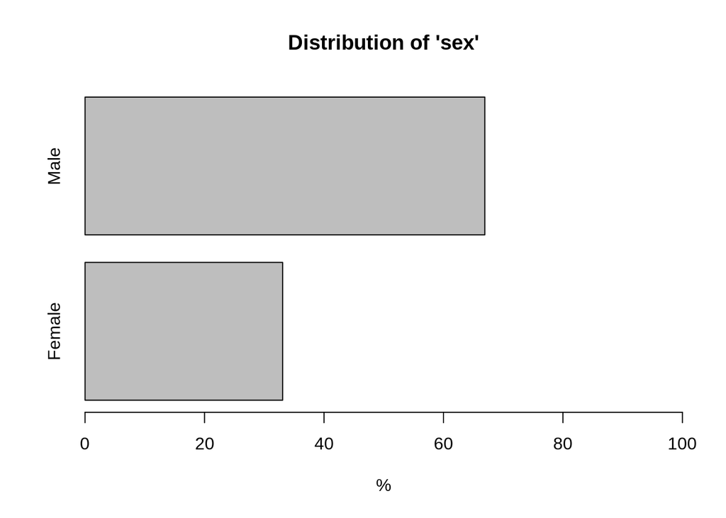

```r
barplot(table.freq$Freq2, names.arg = table.freq$Var1, horiz = TRUE, xlim = c(0,100), xlab = "%", )
title("Distribution of 'sex'")
```

Distribution shows that majority of parctiipants are males (~67%).

### 3 Histogram ‘age’

Plot density.

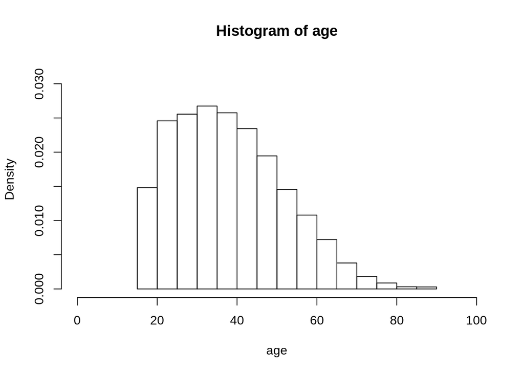

```r
hist(data.pre$age, main = paste('Histogram of age'), freq = FALSE, ylim = c(0, 0.032), xlim = c(0,100), xlab = "age")
```

Plot frequencies.

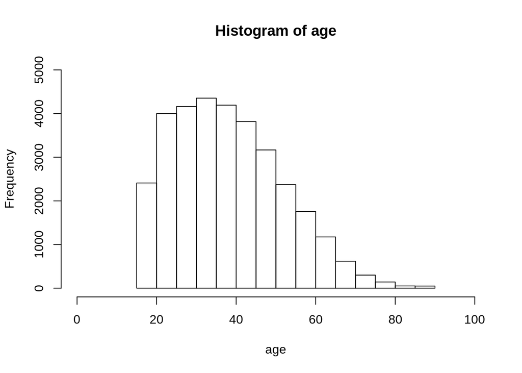

```r
hist(data.pre$age, main = paste('Histogram of age'), freq = TRUE, ylim = c(0,5000), xlim = c(0,100), xlab = "age")
```

Above histograms show the distribution of age in population. Minimum age is about 16. The most numerous group are people in age between 30 and 40. There are few people over 80.

### 4 Analysis of ‘native americans’

For this purpose I’ll create new auxiliary column (nat_ame):  
0 - not native  
1 - native (‘native-country’ = United-States or Outlying-US(Guam-USVI-etc))

```r
data.pre$nat_ame <- 0
data.pre$nat_ame[data.pre$`native-country` == 'United-States' | data.pre$`native-country` == 'Outlying-US(Guam-USVI-etc)'] <- 1
```

Prepare data before plotting barplot. We need to compute shares of all categories.

```r
table <- as.data.frame(table(data.pre$nat_ame))
table.freq <- mutate(table, Freq2 = round(Freq / sum(Freq) * 100, 2))
```

Plot data.

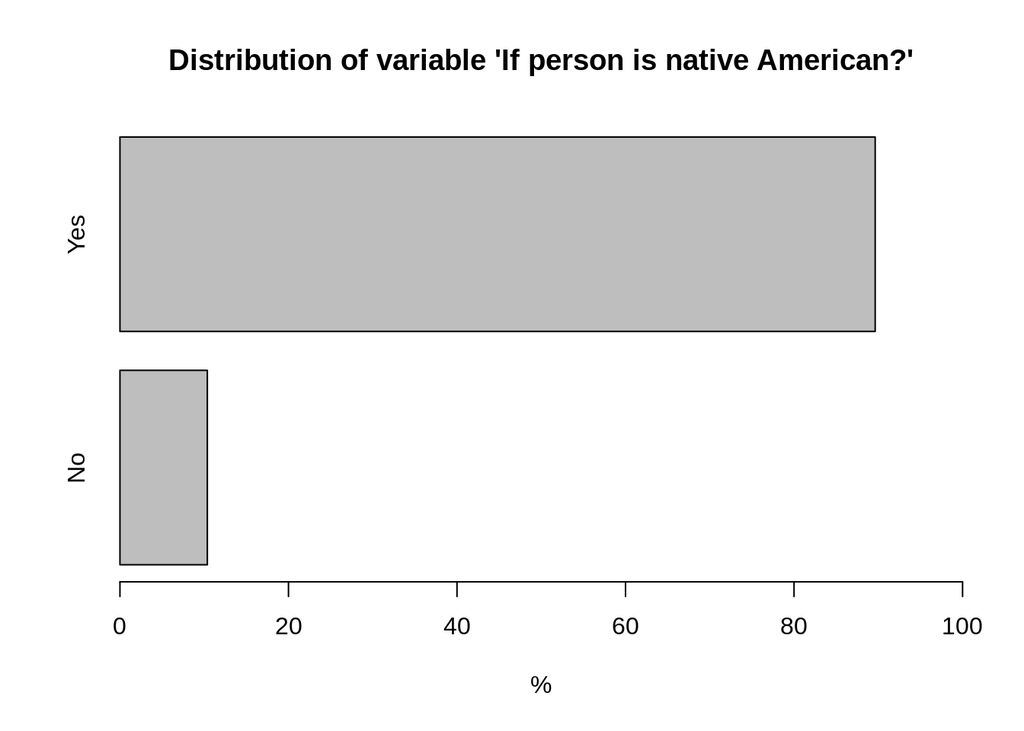

```r
barplot(table.freq$Freq2, names.arg = c("No", "Yes"), horiz = T, xlim = c(0,100), xlab = "%")
title("Distribution of variable 'If person is native American?'")
```

### 5 Analysis of ‘hours-per-week’

First look to data.

```r
table(data.pre$workclass)
```

```
##
##      Federal-gov        Local-gov     Never-worked          Private
##              960             2093                7            22696
##     Self-emp-inc Self-emp-not-inc        State-gov      Without-pay
##             1116             2541             1298               14
```

The workclass categories aren’t equal cardinality. The majority represents Private. Never-worked and Without-pay are the two least numerous groups.  
Violin plot will show difrences in distributions and positional statistics like mean marked with a black dot and median marked with a red dot.

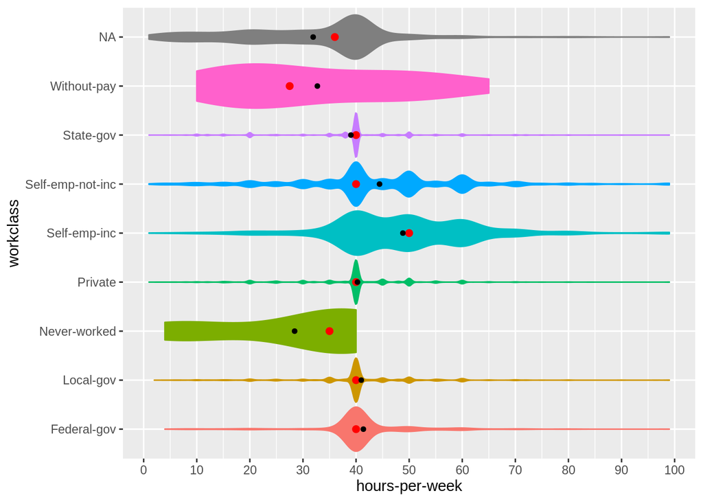

```r
ggplot(data.pre, aes(x=workclass, y=`hours-per-week`, color=workclass, fill=workclass)) + geom_violin( scale="width", trim = T) + coord_flip() + stat_summary(fun.y=median, geom="point", size=2, color="red") + stat_summary(fun.y=mean, geom="point", shape=20, size=2, color = 'black') + theme(legend.position="none") + scale_y_continuous(breaks=seq(0,100,10))
```

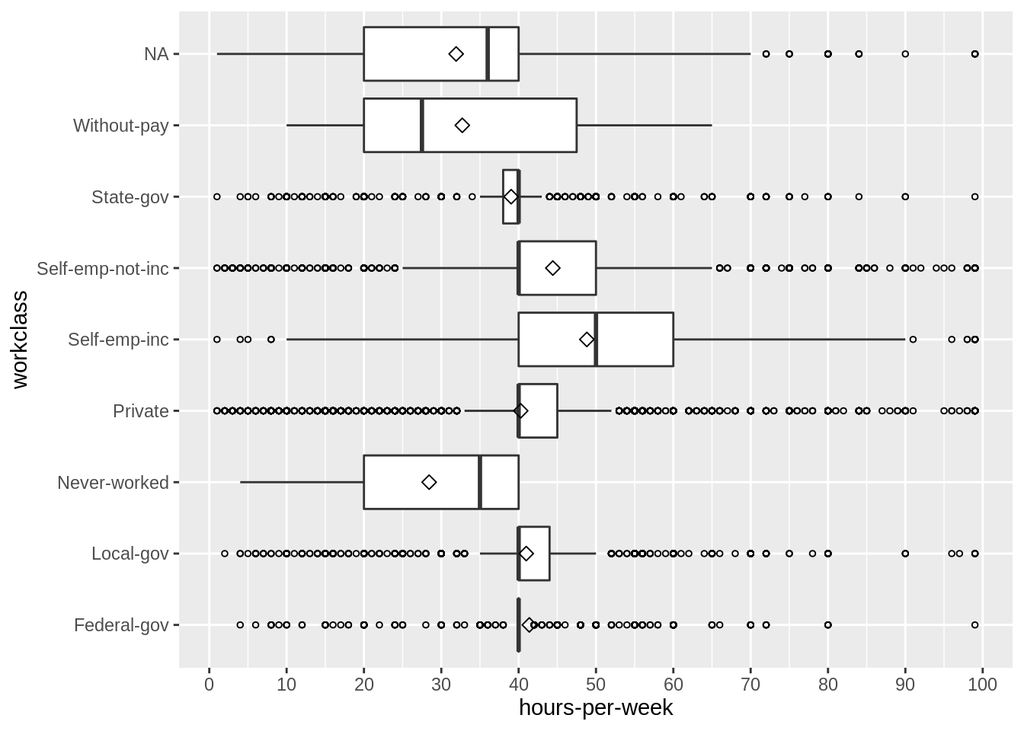

```r
ggplot(data.pre, aes(x=workclass, y=`hours-per-week`)) + geom_boxplot(outlier.colour="black", outlier.shape=1, outlier.size=1, notch=F) + coord_flip() + stat_summary(fun.y=mean, geom="point", shape=5, size=2, color = 'black') + scale_y_continuous(breaks=seq(0,100,10))
```

### 6 Analysis of working time of people under 30 by education

Filtr data and summarize statistics by group.

```r
tab.wyn <- filter(data.pre, workclass == 'Private', age < 30) %>% group_by(education) %>% summarise(work_h_avg = mean(`hours-per-week`), work_h_min = min(`hours-per-week`), work_h_max = max(`hours-per-week`), n = n())
tab.wyn <- tab.wyn[order(-tab.wyn$work_h_avg),]
```

Show computed results.

```r
library(knitr)
library(kableExtra)
```

Description:  
work_h_avg - average working hours per week  
work_h_min - minimum working hours per week  
work_h_max - maximum working hours pew week  
n - number of instances

```r
kable(tab.wyn, format = "html", digits=2) %>%  kable_styling("striped", full_width = F)
```

| education | work_h_avg | work_h_min | work_h_max | n |
| --- | --- | --- | --- | --- |
| Doctorate | 49.09 | 18 | 70 | 11 |
| Prof-school | 47.28 | 8 | 99 | 32 |
| Masters | 43.07 | 20 | 99 | 107 |
| 7th-8th | 41.21 | 8 | 99 | 82 |
| 1st-4th | 41.18 | 5 | 96 | 28 |
| Assoc-voc | 40.31 | 5 | 80 | 282 |
| 5th-6th | 40.30 | 12 | 75 | 81 |
| Bachelors | 40.14 | 2 | 99 | 1062 |
| HS-grad | 39.19 | 1 | 99 | 2513 |
| Assoc-acdm | 36.96 | 5 | 80 | 218 |
| 9th | 35.76 | 6 | 70 | 123 |
| Preschool | 35.27 | 15 | 50 | 11 |
| Some-college | 34.06 | 2 | 98 | 2154 |
| 10th | 31.47 | 3 | 84 | 287 |
| 12th | 30.56 | 6 | 60 | 190 |
| 11th | 28.48 | 2 | 99 | 494 |

### 7 Some interesting visualizations

I’m interested in relationship between binary feature class (>50K, <=50K) and other continous variables. To visualize this relationship I will present distribution by class variable.  
Plot hours-per-week by class.

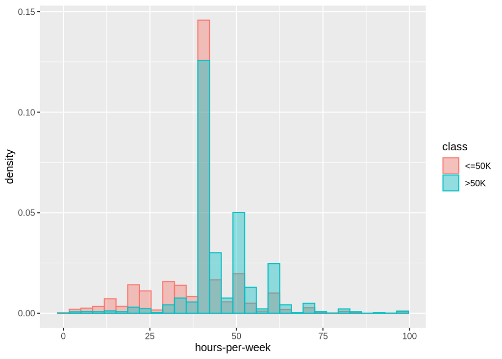

```r
ggplot(data.pre, aes(x = `hours-per-week`)) +  geom_histogram(aes(color = class, fill = class, y = ..density..),  position = "identity", bins = 30, alpha = 0.4)
```

The graph shows difrences between distributions. People with high salary work longer. This feature will be important in class prediction.  
Plot education-num by class.

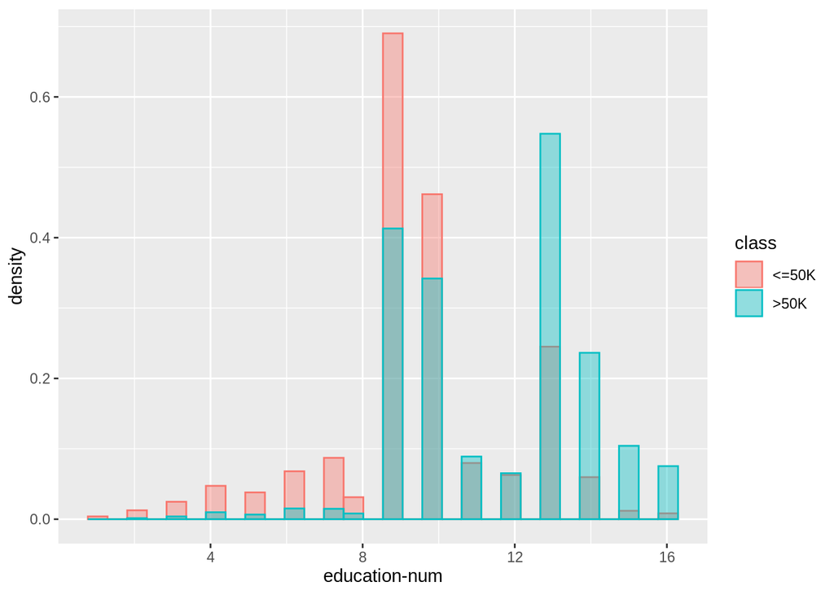

```r
ggplot(data.pre, aes(x = `education-num`)) +  geom_histogram(aes(color = class, fill = class, y = ..density..),  position = "identity", bins = 30, alpha = 0.4)
```

This graph presents that people with higher education earn more money. This feature will be important in class prediction.